# Final_Project

Clarence Williams

December 12, 2019

# Abstract

This project implements the pipeline developed in class to perform named entity recognition, sentiment analysis and document summarization on three main characters and one minor, albeit important character, in Star War The Force Awakens to determine their role in the film.

# Problem Background

The rapid growth of the volume of text documents available has led to the development of techniques to properly ingest documents with the final goal to allow technology to provide insights of human readable text without an actual human reading the document himself/herself Allahyari et al. (2017).

In the analysis, the script of Star War Episode VII: The Force Awakens will analyzed to determine key characters in the script, these characters role in the movie and a summary of their dialog and actions in the film.

# Methodology

The following are the steps taken for the analysis of this script:

1 - Ingest the text

This uses the ingest_text function which can read text, Microsoft Word files, tifs and pdf files. Additionally, functionally was added to allow text to be ingested from a website if the appropriate url and html selector that contains the text has been provided. The code for this function is included below.

```r
#' Module to ingest data from a file
#'
#' @description Takes in a file path and returns the text from the document
#'
#' @importFrom tesseract ocr
#' @importFrom pdftools pdf_convert pdf_text
#' @importFrom tools file_ext
#' @importFrom qdapTools read_docx
#' @importFrom antiword antiword
#' @importFrom magick image_read image_resize image_convert image_trim image_ocr
#' @importFrom data.table fread
#' @importFrom readr read_lines
#' @importFrom quanteda corpus
#' @importFrom rvest html_text html_nodes
#' @importFrom xml2 read_html
#'
#' @param file_path Character string containing the path to the file
#'                  from which the text data is to be extracted
#' @param pdf_image Boolean denoting if the file is an image,
#'                  for use when \code{file_path == 'pdf'}
#' @param file_type Character string to specify the file type
#'
#' @param text_url Character string of URL where text is location
#'
#' @param container character string to specificy HTML class of container where the text resides
#'
#' @example
#' \dontrun{
#'
#' oper655_readme <- "https://raw.githubusercontent.com/AFIT-R/oper655_fa2019/master/README.md"
#'
#' Text = ingest_text(oper655_readme,
#'                    file_type = "txt")
#'
#' }
#'
#' @return text data
ingest_text <-  function(file_path = NULL,
                         pdf_image = F,
                         file_type = NULL,
                         text_url = NULL,
                         container = NULL){

  if(!is.null(text_url) & !is.null(container)){
    #read page html
    page<- xml2::read_html(text_url)
    #extract text from page html using selector
    text_data <- rvest::html_text(rvest::html_nodes(page, container))

    return(text_data)
  }

  if(is.null(file_type)) file_type <- tools::file_ext(file_path)

  text_data <- switch(tolower(file_type),
                      'pdf' = `if`(pdf_image,
                                   tesseract::ocr(pdftools::pdf_convert(file_path, dpi = 600)),
                                   pdftools::pdf_text(file_path)),
                      'docx' = qdapTools::read_docx(file_path),
                      'doc' = antiword::antiword(file_path),
                      'txt' = readr::read_lines(file_path),
                      'csv' = data.table::fread(file_path),
                      'tif' =, "png" = { magick::image_read(image_file) %>%
                                magick::image_resize("2000")   %>%
                                magick::image_convert(colorspace = 'gray') %>%
                                magick::image_trim() %>%
                                magick::image_ocr() })

  return(text_data)

}
```

2 - Perform Named Entity Recognition (NER)

This uses the get_ner function to tokenize the document and extract persons, locations, organizations, products, etc. to identify the most common person enitities

```r
get_ner <-function(text,...){

  spacyr::spacy_initialize(model = "en_core_web_sm")

  ner <- spacyr::spacy_parse(text,...)

  spacyr::spacy_finalize()

  return(ner)

}
```

Once a character has been identified the following code extracts the dialog spoken by the character.

```r
get_sw_charlines <- function (character){

  charact_txt <- sw[which(stringr::str_detect(sw, character))]

  return(charact_txt)
}
```

3 - Character Analysis

- Perform Sentiment Analysis on person entities

  Determine the emotion behind each common entity’s dialog using document-level sentiment classification to determine if the entities are antagonists or protagonists.

The get_sentimentCloud function display 150 words grouped by postive or negative sentiment with the words sized by occurances.

```r
get_sentimentCloud <- function (text_data){tibble::tibble(text = text_data) %>%
  unnest_tokens(word, text) %>%
  inner_join(get_sentiments("bing")) %>%
  count(word, sentiment, sort = TRUE) %>%
  acast(word ~ sentiment, value.var = "n", fill = 0) %>%
  comparison.cloud(colors = c("gray20","gray80"),
                   max.words = 150)
}
```

- Perfrom Document Summarization on person entities

The document summarization implemented in this project uses extractive document summarization to identify the most important and most frequent text within a document and output the sentences which capture the best summary of the document. These best sentences are taken directly from the document. The code below shows the implementation of the get_summary function which uses the page rank algorithm.

```r
get_summary <- function(text,
                        n_sentences,...) {

  top_n = lexRankr::lexRank(text,
                            #only 1 article; repeat same docid for all of input vector
                            docId = rep(1, length(text)),
                            #return 3 sentences to mimick /u/autotldr's output
                            n = n_sentences,
                            continuous = TRUE,...)

#reorder the top n sentences to be in order of appearance in article
order_of_appearance = order(as.integer(gsub("_","",top_n$sentenceId)))

#extract sentences in order of appearance
ordered_top_n = top_n[order_of_appearance, "sentence"]
ordered_top_n

return(ordered_top_n)

}
```

## 1 - Ingest the text

The text for this analysis is ingested from a website using the ingest text function. On the imsdb website, the script resides in a html table tag with the class scrtext. Other scripts on this website reside in same table tag on their respective pages. So, the ingest text function should work for any script on this website.

```r
pacman::p_load(tidyr,
               tidytext,
               tidyverse,
               textdata,
               dplyr,
               stringr,
               ggplot2,
               magrittr,
               wordcloud,
               reshape2,
               monkeylearn,
               quanteda,
               spacyr,
               NLP,
               LSAfun,
               xml2,
               rvest,
               lexRankr)

fa_text <- ingest_text(text_url = "https://www.imsdb.com/scripts/Star-Wars-The-Force-Awakens.html", container = ".scrtext")
```

After reading in the text, viewing a subset of the script reveals that character dialog can span multiple lines. This can be problematic if one wants to get the dialog spoken by a particular character due to risk of truncation.

```r
write_lines(fa_text, "fa.txt")

fa_orig <-readLines("fa.txt")
fa_orig[326:330]
```

```
[1] "                          POE"
[2] "           ... Apparatus."
[3] "          The Troopers roughly pull Poe away. A Stormtrooper begins a"
[4] "          brutal PAT DOWN. Kylo Ren moves closer."
[5] "          Poe just glares as the pat down ends."
```

To mitigate the potential truncation of character dialog, it is necessary to remove single new lines but keep consecutive newlines to preserve the structure of the script where dialog follows a character’s name that is capitalized. This is accomplished using regular expressions (regex) which places each occurrence of dialog on a separate element of a character vector.

```r
fa_clean <- stringr::str_replace_all(fa_text, "\r", "")
fa_clean <- gsub("(?<!\n)\n(?!\n)|\n{3,}", "", fa_clean, perl=TRUE)


#stu3 <- str_remove_all(stu2, fixed("\t"))
write_lines(fa_clean, "sw_fa.txt")

sw <- readLines("sw_fa.txt")
```

After cleaning the data using the regex the same lines now look like the following.

```r
sw[171]
```

```
[1] "                          POE           ... Apparatus.          The Troopers roughly pull Poe away. A Stormtrooper begins a          brutal PAT DOWN. Kylo Ren moves closer.          Poe just glares as the pat down ends."
```

## 2 - Perform NER

The person entities returned by NER show that Ray, Finn and Kylo Ren are the most common entities of that type. However, examining the most frequent words in the script reveals that Han should also be a common entity that is a person as well.

[figure not shown]

```r
fa_ner2<- get_ner(sw)

fa_ner_extracted <- entity_extract(fa_ner2)

fa_ner_extracted %>%
  filter(entity_type == "PERSON" ) %>%
  group_by(entity_type) %>%
  count(entity) %>%
  top_n(10) %>%
  ggplot(aes(x = entity, y = n)) +
  geom_bar(stat = "identity") +
  theme(axis.text.x = element_text(angle = 90, hjust = 1)) +
  labs(title = "Entities that are Persons") +
  xlab("Persons") +
  ylab("Mentions")
```

```r
text_tb <- tibble::tibble(text = fa_clean)

 text_tb %>%
  tidytext::unnest_tokens(word, text, token = 'words') %>%
  dplyr::anti_join(stop_words) %>%
  dplyr::count(word, sort = TRUE)  %>%
  top_n(10)
```

```
# A tibble: 10 x 2
   word      n
   <chr> <int>
 1 rey     417
 2 finn    400
 3 han     305
 4 day     222
 5 ren     179
 6 kylo    175
 7 bb      159
 8 int     157
 9 poe     156
10 8       155
```

In this case, NER erroneously labeled Han as NORP which is a Nationality or religious or political group.

```r
han <- fa_ner_extracted %>%
  filter(entity == "Han" )

han[1:5, ]
```

```
    doc_id sentence_id entity entity_type
1 text1303           2    Han        NORP
2 text1303           3    Han        NORP
3 text1303           5    Han        NORP
4 text1339           3    Han        NORP
5 text1339           4    Han        NORP
```

Lets investigate the top three person entities returned by NER which is Rey, Finn and Klyo to determine their role in the story.

## 3 - Character Analysis

### Rey

Sentiment analysis on Rey reveals that falls, confused, dark and nervously are the most frequent negative emotions she experiences throughout the movie but she also experiences joy as shown by smiles, good, grateful. This is evidence that she may be a protagonist who is put under duress by another character in the film.

Additionally, Resistance is the most negative word but that could be a mistake since the Resistance is a group of people in the film.

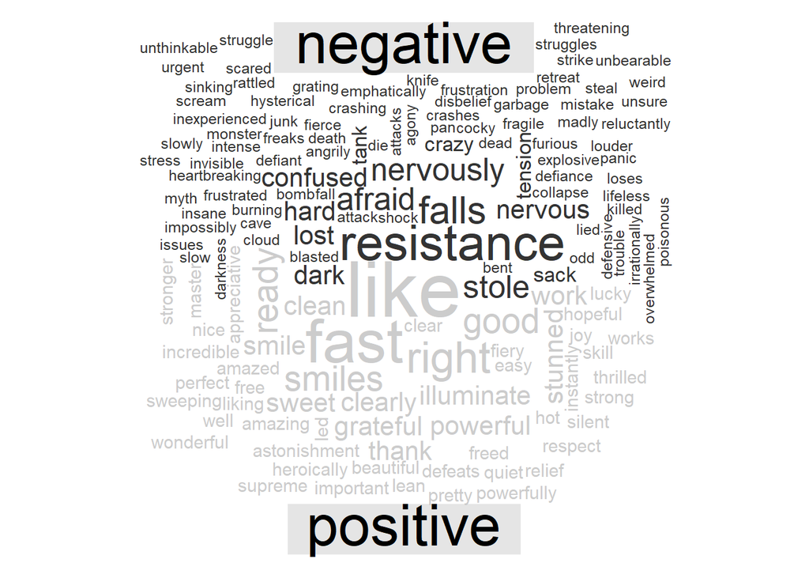

```r
rey_txt <- get_sw_charlines("REY")

get_sentimentCloud(rey_txt)
```

Summarization of Reys text reveals is a captive at some point in the movie but it is not clear yet if she is a hero or villian in the story.

```r
get_summary(rey_txt,5)
```

```
Parsing text into sentences and tokens...DONE
Calculating pairwise sentence similarities...DONE
Applying LexRank...DONE
Formatting Output...DONE
```

```
[1] "BB-8 reacts          nervously as Rey resists them -- one pulls a SACK over BB-8          while the other grabs Rey's arm -- in the tussle, Rey KNOCKS          OVER METAL URNS for sale --          Finn, still drinking, is PUSHED OVER by the happabore."
[2] "Finn and Rey race past BB-8 -- as they go up the ramp, Han          says to Rey:"
[3] "FINN takes out 2 TROOPERS with the blaster, then, out of          breath, turns to see: Kylo Ren in the forest, CARRYING REY          IN HIS ARMS, INTO HIS SHUTTLE!"
[4] "In crazed frustration, Finn stops running, watches the          receding First Order ships, Rey their captive."
[5] "Finn turns -- AND SEES REY, CLIMBING OUT FROM INSIDE THE          WALL, carefully climbing back up to the main level!"
```

### Finn

Like Rey, Finn experiences a variety of negative emotions throughout the movie. Again at this point in the analysis, his role is unclear but it is reasonable to conclude that he is put under duress by another character in the film.

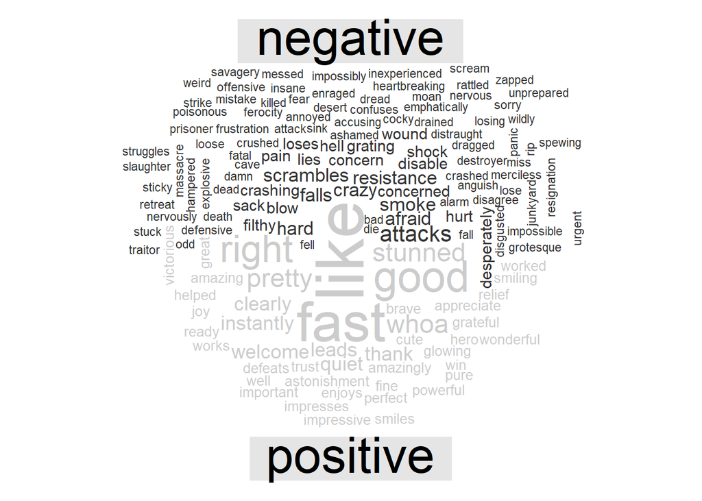

```r
finn_txt <- get_sw_charlines("FINN")

get_sentimentCloud(finn_txt)
```

The summarization of Finn’s dialog is very similar to Rey’s summarization. This means that the two characters could have the same role and are paired up frequently throughout the movie.

```r
get_summary(finn_txt,5)
```

```
Parsing text into sentences and tokens...DONE
Calculating pairwise sentence similarities...DONE
Applying LexRank...DONE
Formatting Output...DONE
```

```
[1] "Her eyes light          up as she moves to it: a BANK OF VIDEO MONITORS OF THE SHIP --          and there's Finn, being dragged by a Rathtar toward an OPEN          BLAST DOOR."
[2] "Han and Rey race up the ramp as Finn heads up with Chewie,          who SCREAMS WILDLY IN PAIN!"
[3] "She follows the sound into          the castle, turning so she can't see that Finn has looked          back at her one last time."
[4] "In crazed frustration, Finn stops running, watches the          receding First Order ships, Rey their captive."
[5] "Kylo Ren SEES REY AND FINN, WATCHING THE EXPLOSIONS IN SHOCK --          then they SEE KYLO REN, WHO RECOGNIZES THEM BOTH, WITH          ASTONISHMENT."
```

### Kylo Ren

There are more negative emotions associated with Kylo Ren than positive which suggest he could be an antagonist.

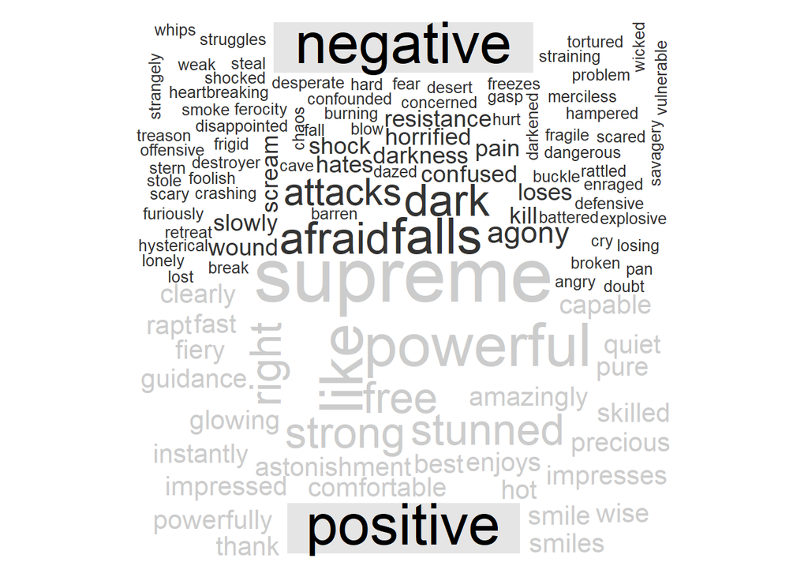

```r
kylo_txt <- get_sw_charlines("KYLO")

get_sentimentCloud(kylo_txt)
```

```r
get_summary(kylo_txt,5)
```

```
Parsing text into sentences and tokens...DONE
Calculating pairwise sentence similarities...DONE
Applying LexRank...DONE
Formatting Output...DONE
```

```
[1] "Rey's body          is released, she breathes deeply, her powerful eyes still on          Kylo Ren, who starts to leave."
[2] "Kylo Ren SEES REY AND FINN, WATCHING THE EXPLOSIONS IN SHOCK --          then they SEE KYLO REN, WHO RECOGNIZES THEM BOTH, WITH          ASTONISHMENT."
[3] "Kylo Ren RAISES A HAND -- Rey struggles under his FORCE POWER --          she can't fire -- he strains too, especially with the WOUND          Chewie inflicted."
[4] "Kylo Ren GESTURES POWERFULLY -- Rey's          BLASTER FLIES OUT OF HER HAND -- another GESTURE and Rey          FLIES BACK and SLAMS INTO A TREE thirty feet away!"
[5] "Rey sees this -- Kylo Ren unleashes a MERCILESS SERIES OF          BLOWS, pushing Finn further and further back until he loses          balance."
```

### Snoke

Additionally, prior knowledge of the film reveals the Snoke is the main villain despite his limited screen time. Let see if sentiment analysis and document summarization of his dialog backs this claim

Sentiment analysis and document summarization on Snoke’s dialog clearly reveals that he is a villain like Kylo Ren. The fifth line of the summarization also reveals that he is possibly a commander since he is giving orders.

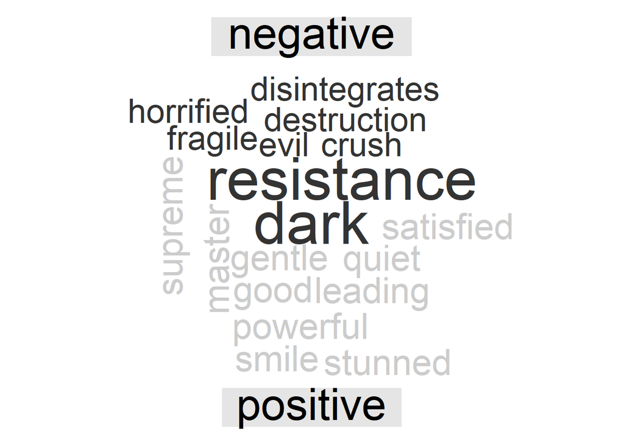

```r
snoke_txt <- get_sw_charlines("SNOKE")

get_sentimentCloud(snoke_txt)
```

```r
get_summary(snoke_txt,5)
```

```
Parsing text into sentences and tokens...DONE
Calculating pairwise sentence similarities...DONE
Applying LexRank...DONE
Formatting Output...DONE
```

```
[1] "SNOKE           Go. Oversee preparations."
[2] "SNOKE           Even you, master of the Knights of           Ren, have never faced such a test."
[3] "A gentle, satisfied nod from Snoke, and Kylo Ren, obsessed,          filled up, exits."
[4] "SNOKE           And the droid?"
[5] "SNOKE           Leave the base at once and come to           me with Kylo Ren."
```

### Wikipedia Summumary

For reference the summarization of the movie from wikipedia can be viewed at the following link.

[Star Wars: The Force Awakens Plot](https://en.wikipedia.org/wiki/Star_Wars:_The_Force_Awakens#Plot)

# Conclusions

Overall, the pipeline was able to successfully ingest the script and perform NER, sentiment analysis and document summarization on the dialog of three of the main characters of the Force Awakens. The summarization of the three main characters’ text is a reasonable approximation of the human generated wikipedia summary. Additional applications of this pipeline are extensive in that rather than watching a 2-hour film or reading a 100-page document, key information can be obtained in minutes. A shortcoming with this approach is that it is unsupervised, which therefore requires human generated analysis to provide confirmation that the machine generated reasonable results. Future work could implement separate supervised approaches for ingesting multiple scripts for summarization and character role classification provided that a known result has been provided.

# References

Allahyari, Mehdi, Seyedamin Pouriyeh, Mehdi Assefi, Saeid Safaei, Elizabeth D., Juan B., and Krys Kochut. 2017. “Text Summarization Techniques: A Brief Survey.” *International Journal of Advanced Computer Science and Applications* 8 (10). https://doi.org/10.14569/ijacsa.2017.081052.